# Articulatory Analysis

Tabea Thies

2022-09-13

# Analysis of tongue body movements comparing med-OFF and med-ON

Load necessary packages

```r
library(tidyverse)
library(ggplot2)
library(lme4)
library(lmerTest)
library(merTools)
library(sjPlot)
library(sjmisc)
```

Load data set

```r
data <- read_csv('../data/articulation.csv')
```

Create subset for the comparison med-OFF vs med-ON

```r
data_red <-  filter(data, med_con %in% c('med-OFF', 'med-ON'))
```

# Movement duration

Descriptive stats for reporting values in Section 7.2.3

```r
DUR_stats <- data_red %>%
  group_by(med_con) %>%
  summarise(M = round(mean(GAI_V1)),
            SD = round(sd(GAI_V1)))
DUR_stats
```

```
## # A tibble: 2 x 3
##   med_con     M    SD
##   <chr>   <dbl> <dbl>
## 1 med-OFF   194    46
## 2 med-ON    187    47
```

```r
DUR_stats2 <- data_red %>%
  group_by(med_con, focus_con) %>%
  summarise(M = round(mean(GAI_V1)),
            SD = round(sd(GAI_V1)))
DUR_stats2
```

```
## # A tibble: 6 x 4
## # Groups:   med_con [2]
##   med_con focus_con       M    SD
##   <chr>   <chr>       <dbl> <dbl>
## 1 med-OFF background    186    43
## 2 med-OFF broad         193    45
## 3 med-OFF contrastive   203    49
## 4 med-ON  background    180    42
## 5 med-ON  broad         188    45
## 6 med-ON  contrastive   193    53
```

Plot tongue body movement duration

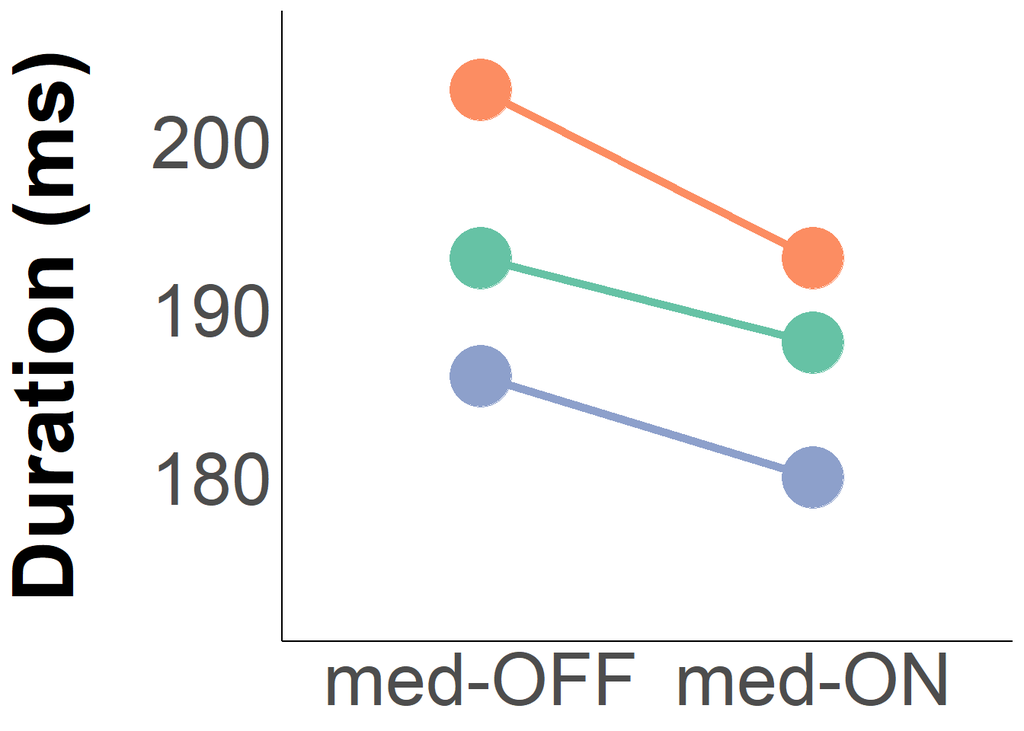

```r
DUR_stats2 %>%
  ggplot(aes(x=med_con, y=M, group = focus_con, col=focus_con)) +
  geom_line(size = 2) +
  geom_point(size = 14)+
  theme_classic() +
  theme(legend.position = 'none')+
  theme(legend.title = element_blank(),
        legend.text = element_text(size = 36))+
  scale_color_manual(values = c("#8da0cb", "#66c2a5", "#fc8d62")) +
  xlab(NULL) +
  scale_x_discrete(labels = c('med-OFF','med-ON'))+
  coord_cartesian(ylim = c(172, 206)) +
  scale_y_continuous(breaks = seq(180, 200, 10)) +
  ylab("Duration (ms)")+
  theme(axis.title.y = element_text(face = 'bold', size = 42, margin = margin(r = 30)))+
  theme(strip.text.x = element_text(size=38, face="bold"),
        strip.background = element_blank())+
  theme(axis.text.x = element_text(size = 36),
        axis.text.y = element_text(size = 36)) +
  theme(axis.ticks.x = element_blank(),
        axis.ticks.y = element_blank())
```

Create linear mixed model to investigate disease effect on TB duration

```r
mdl <- lmer(GAI_V1 ~ med_con + focus_con + vowel + cons + age  + (1 + focus_con+med_con|speaker), data_red, REML = FALSE)
```

Look at model summary

```r
summary(mdl)
```

```
## Linear mixed model fit by maximum likelihood . t-tests use Satterthwaite's
##   method [lmerModLmerTest]
## Formula: GAI_V1 ~ med_con + focus_con + vowel + cons + age + (1 + focus_con +
##     med_con | speaker)
##    Data: data_red
##
##      AIC      BIC   logLik deviance df.resid
##   7723.3   7821.2  -3840.6   7681.3      763
##
## Scaled residuals:
##     Min      1Q  Median      3Q     Max
## -3.5583 -0.6630 -0.0737  0.6441  4.0393
##
## Random effects:
##  Groups   Name                 Variance Std.Dev. Corr
##  speaker  (Intercept)          598.565  24.466
##           focus_conbroad         9.463   3.076   1.00
##           focus_concontrastive 106.346  10.312   0.82 0.82
##           med_conmed-ON        131.586  11.471   0.18 0.18 0.71
##  Residual                      967.099  31.098
## Number of obs: 784, groups:  speaker, 13
##
## Fixed effects:
##                      Estimate Std. Error       df t value Pr(>|t|)
## (Intercept)          148.1892    45.8256  15.0001   3.234  0.00557 **
## med_conmed-ON         -7.4485     3.8805  13.0361  -1.919  0.07708 .
## focus_conbroad         7.6385     2.8492  68.0105   2.681  0.00921 **
## focus_concontrastive  15.2158     3.9455  16.3687   3.856  0.00135 **
## vowele               -11.0521     3.4852 756.6665  -3.171  0.00158 **
## voweli                -7.2572     3.5515 756.7036  -2.043  0.04136 *
## vowelo               -13.0971     3.5275 756.6918  -3.713  0.00022 ***
## vowelu               -18.4218     3.5216 756.6260  -5.231 2.18e-07 ***
## conslab              -12.3804     2.2218 756.6708  -5.572 3.50e-08 ***
## age                    0.9264     0.7670  14.8126   1.208  0.24605
## ---
## Signif. codes:  0 '***' 0.001 '**' 0.01 '*' 0.05 '.' 0.1 ' ' 1
##
## Correlation of Fixed Effects:
##             (Intr) md_-ON fcs_cnb fcs_cnc vowele voweli vowelo vowelu conslb
## med_cnmd-ON  0.008
## focus_cnbrd  0.013  0.044
## fcs_cncntrs  0.066  0.419  0.505
## vowele      -0.037 -0.001  0.005   0.007
## voweli      -0.034  0.003  0.005   0.002   0.504
## vowelo      -0.033  0.001  0.007   0.003   0.508  0.498
## vowelu      -0.037  0.002  0.005   0.003   0.508  0.499  0.502
## conslab     -0.031  0.004  0.003   0.002   0.002 -0.006 -0.006 -0.004
## age         -0.986 -0.001  0.003   0.002  -0.003 -0.005 -0.006 -0.002  0.006
## optimizer (nloptwrap) convergence code: 0 (OK)
## boundary (singular) fit: see help('isSingular')
```

extracting fit statistics for reporting in text

```r
tab_model(mdl)
```

|  | GAI V 1 |  |  |
| --- | --- | --- | --- |
| Predictors | Estimates | CI | p |
| (Intercept) | 148.19 | 58.23 – 238.15 | **0.001** |
| med con [med-ON] | -7.45 | -15.07 – 0.17 | 0.055 |
| focus con [broad] | 7.64 | 2.05 – 13.23 | **0.008** |
| focus con [contrastive] | 15.22 | 7.47 – 22.96 | **<0.001** |
| vowel [e] | -11.05 | -17.89 – -4.21 | **0.002** |
| vowel [i] | -7.26 | -14.23 – -0.29 | **0.041** |
| vowel [o] | -13.10 | -20.02 – -6.17 | **<0.001** |
| vowel [u] | -18.42 | -25.33 – -11.51 | **<0.001** |
| cons [lab] | -12.38 | -16.74 – -8.02 | **<0.001** |
| age | 0.93 | -0.58 – 2.43 | 0.227 |
| Random Effects |  |  |  |
| σ<sup>2</sup> | 967.10 |  |  |
| τ<sub>00</sub> <sub>speaker</sub> | 598.56 |  |  |
| τ<sub>11</sub> <sub>speaker.focus_conbroad</sub> | 9.46 |  |  |
| τ<sub>11</sub> <sub>speaker.focus_concontrastive</sub> | 106.35 |  |  |
| τ<sub>11</sub> <sub>speaker.med_conmed-ON</sub> | 131.59 |  |  |
| ρ<sub>01</sub> | 1.00 |  |  |
|  | 0.82 |  |  |
|  | 0.18 |  |  |
| N <sub>speaker</sub> | 13 |  |  |
| Observations | 784 |  |  |
| Marginal R<sup>2</sup> / Conditional R<sup>2</sup> | 0.161 / NA |  |  |

## Explore random effects with function REsim

Effects for individual levels are simulated  
Output: mean, median and sd of the random effect estimates

Plots estimated random effects for each participant  
95 % Intervals that do not overlap zero are bold

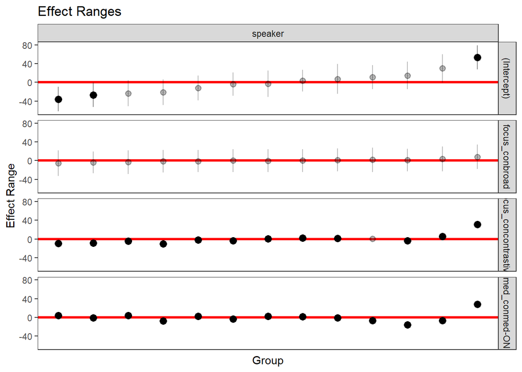

```r
randoms <- REsim(mdl)
plotREsim(randoms)
```

Plot estimated 95 % interval spans for the intercept of TB duration

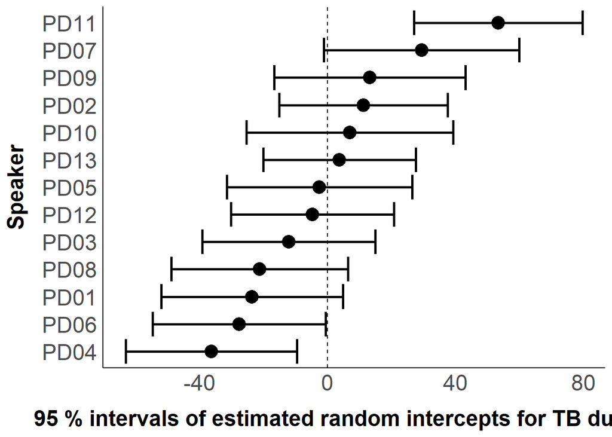

```r
random2 <- subset(randoms, term == "(Intercept)")

random2 %>%
  ggplot(aes(x = mean, xmin = mean-sd-sd, xmax = mean+sd+sd, y = reorder(groupID, mean))) +
  geom_vline(xintercept = 0, linetype = 'dashed') +
  geom_point(size = 5)+
  geom_errorbar(size = 1) +
  theme_classic()+
  xlab('95 % intervals of estimated random intercepts for TB duration') +
  ylab('Speaker')+
  theme(axis.title.y = element_text(face = 'bold', size = 18, margin = margin(r = 12)))+
  theme(axis.title.x = element_text(face = 'bold', size = 18, margin = margin(t = 12)))+
  theme(strip.text.x = element_text(size=18, face="bold"),
        strip.background = element_blank())+
  theme(axis.text.x = element_text(size = 18),
        axis.text.y = element_text(size = 18)) +
  theme(axis.ticks.x = element_blank(),
        axis.ticks.y = element_blank())+
  theme(legend.position = "top",
        legend.title = element_blank(),
        legend.text = element_text(size = 18))
```

Plot estimated 95 % interval spans for the slope of TB duration

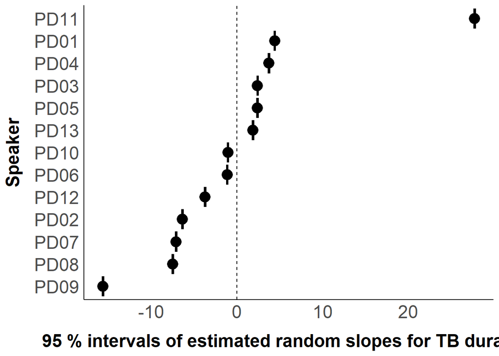

```r
random3 <- subset(randoms, term == "med_conmed-ON")

random3 %>%
  ggplot(aes(x = mean, xmin = mean-sd-sd, xmax = mean+sd+sd, y = reorder(groupID, mean))) +
  geom_vline(xintercept = 0, linetype = 'dashed') +
  geom_point(size = 5)+
  geom_errorbar(size = 1) +
  theme_classic()+
  xlab('95 % intervals of estimated random slopes for TB duration') +
  ylab('Speaker')+
  theme(axis.title.y = element_text(face = 'bold', size = 18, margin = margin(r = 12)))+
  theme(axis.title.x = element_text(face = 'bold', size = 18, margin = margin(t = 12)))+
  theme(strip.text.x = element_text(size=18, face="bold"),
        strip.background = element_blank())+
  theme(axis.text.x = element_text(size = 18),
        axis.text.y = element_text(size = 18)) +
  theme(axis.ticks.x = element_blank(),
        axis.ticks.y = element_blank())+
  theme(legend.position = "top",
        legend.title = element_blank(),
        legend.text = element_text(size = 18))
```

# Movement amplitude

Descriptive stats for reporting values in Section 7.2.3

```r
DISPL_stats <- data_red %>%
  group_by(med_con) %>%
  summarise(M = round(mean(disp_V1_abs),1),
            SD = round(sd(disp_V1_abs),1))
DISPL_stats
```

```
## # A tibble: 2 x 3
##   med_con     M    SD
##   <chr>   <dbl> <dbl>
## 1 med-OFF   7.8   4.5
## 2 med-ON    7.5   4.4
```

```r
DISPL_stats2 <- data_red %>%
  group_by(med_con, focus_con) %>%
  summarise(M = round(mean(disp_V1_abs),1),
            SD = round(sd(disp_V1_abs),1))
DISPL_stats2
```

```
## # A tibble: 6 x 4
## # Groups:   med_con [2]
##   med_con focus_con       M    SD
##   <chr>   <chr>       <dbl> <dbl>
## 1 med-OFF background    7.4   4.2
## 2 med-OFF broad         7.9   4.5
## 3 med-OFF contrastive   8     4.8
## 4 med-ON  background    7.2   4.2
## 5 med-ON  broad         7.5   4.5
## 6 med-ON  contrastive   7.9   4.5
```

Plot tongue body movement amplitude

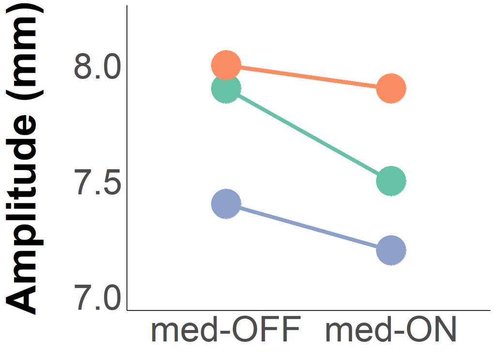

```r
DISPL_stats2 %>%
  ggplot(aes(x=med_con, y=M, group = focus_con, col=focus_con)) +
  geom_line(size = 2) +
  geom_point(size = 14)+
  theme_classic() +
  theme(legend.position = 'none')+
  theme(legend.title = element_blank(),
        legend.text = element_text(size = 36))+
  scale_color_manual(values = c("#8da0cb", "#66c2a5", "#fc8d62")) +
  coord_cartesian(ylim = c(7, 8.2)) +
  scale_y_continuous(breaks = seq(7, 8, 0.5)) +
  xlab(NULL) +
  scale_x_discrete(labels = c('med-OFF','med-ON'))+
  ylab("Amplitude (mm)")+
  theme(axis.title.y = element_text(face = 'bold', size = 42, margin = margin(r = 30)))+
  theme(strip.text.x = element_text(size=38, face="bold"),
        strip.background = element_blank())+
  theme(axis.text.x = element_text(size = 36),
        axis.text.y = element_text(size = 36)) +
  theme(axis.ticks.x = element_blank(),
        axis.ticks.y = element_blank())
```

Create linear mixed model to investigate disease effect on TB amplitude

```r
mdl2 <- lmer(disp_V1_abs ~ med_con + focus_con + vowel + cons + age  + (1 + focus_con+med_con|speaker), data_red, REML = FALSE)
```

Look at model summary

```r
summary(mdl2)
```

```
## Linear mixed model fit by maximum likelihood . t-tests use Satterthwaite's
##   method [lmerModLmerTest]
## Formula: disp_V1_abs ~ med_con + focus_con + vowel + cons + age + (1 +
##     focus_con + med_con | speaker)
##    Data: data_red
##
##      AIC      BIC   logLik deviance df.resid
##   3624.5   3722.4  -1791.2   3582.5      763
##
## Scaled residuals:
##     Min      1Q  Median      3Q     Max
## -5.4729 -0.6021 -0.0270  0.6311  3.1226
##
## Random effects:
##  Groups   Name                 Variance Std.Dev. Corr
##  speaker  (Intercept)          1.483896 1.21815
##           focus_conbroad       0.001863 0.04316  1.00
##           focus_concontrastive 0.021951 0.14816  0.58 0.58
##           med_conmed-ON        0.186317 0.43164  0.43 0.43 0.98
##  Residual                      5.336841 2.31016
## Number of obs: 784, groups:  speaker, 13
##
## Fixed effects:
##                       Estimate Std. Error        df t value Pr(>|t|)
## (Intercept)            5.53825    2.68844  13.07806   2.060  0.05987 .
## med_conmed-ON         -0.26381    0.20389  12.16983  -1.294  0.21972
## focus_conbroad         0.44923    0.20228 485.36703   2.221  0.02682 *
## focus_concontrastive   0.62491    0.20602  99.54405   3.033  0.00309 **
## vowele                -7.88811    0.25889 746.47142 -30.468  < 2e-16 ***
## voweli                -5.94543    0.26381 746.53183 -22.537  < 2e-16 ***
## vowelo                -4.93878    0.26203 746.63730 -18.848  < 2e-16 ***
## vowelu               -10.21826    0.26160 746.39316 -39.060  < 2e-16 ***
## conslab                0.75905    0.16504 746.44564   4.599 4.98e-06 ***
## age                    0.12474    0.04507  12.93668   2.768  0.01605 *
## ---
## Signif. codes:  0 '***' 0.001 '**' 0.01 '*' 0.05 '.' 0.1 ' ' 1
##
## Correlation of Fixed Effects:
##             (Intr) md_-ON fcs_cnb fcs_cnc vowele voweli vowelo vowelu conslb
## med_cnmd-ON  0.006
## focus_cnbrd -0.029  0.015
## fcs_cncntrs -0.023  0.115  0.492
## vowele      -0.050 -0.001  0.005   0.009
## voweli      -0.044  0.005  0.005   0.002   0.504
## vowelo      -0.045  0.002  0.007   0.005   0.508  0.498
## vowelu      -0.048  0.003  0.005   0.005   0.508  0.499  0.502
## conslab     -0.034  0.006  0.003   0.003   0.002 -0.006 -0.006 -0.004
## age         -0.988  0.000 -0.001   0.000   0.000 -0.005 -0.004 -0.001  0.003
## optimizer (nloptwrap) convergence code: 0 (OK)
## boundary (singular) fit: see help('isSingular')
```

extracting fit statistics for reporting in text

```r
tab_model(mdl2)
```

|  | disp V 1 abs |  |  |
| --- | --- | --- | --- |
| Predictors | Estimates | CI | p |
| (Intercept) | 5.54 | 0.26 – 10.82 | **0.040** |
| med con [med-ON] | -0.26 | -0.66 – 0.14 | 0.196 |
| focus con [broad] | 0.45 | 0.05 – 0.85 | **0.027** |
| focus con [contrastive] | 0.62 | 0.22 – 1.03 | **0.003** |
| vowel [e] | -7.89 | -8.40 – -7.38 | **<0.001** |
| vowel [i] | -5.95 | -6.46 – -5.43 | **<0.001** |
| vowel [o] | -4.94 | -5.45 – -4.42 | **<0.001** |
| vowel [u] | -10.22 | -10.73 – -9.70 | **<0.001** |
| cons [lab] | 0.76 | 0.44 – 1.08 | **<0.001** |
| age | 0.12 | 0.04 – 0.21 | **0.006** |
| Random Effects |  |  |  |
| σ<sup>2</sup> | 5.34 |  |  |
| τ<sub>00</sub> <sub>speaker</sub> | 1.48 |  |  |
| τ<sub>11</sub> <sub>speaker.focus_conbroad</sub> | 0.00 |  |  |
| τ<sub>11</sub> <sub>speaker.focus_concontrastive</sub> | 0.02 |  |  |
| τ<sub>11</sub> <sub>speaker.med_conmed-ON</sub> | 0.19 |  |  |
| ρ<sub>01</sub> | 1.00 |  |  |
|  | 0.58 |  |  |
|  | 0.43 |  |  |
| N <sub>speaker</sub> | 13 |  |  |
| Observations | 784 |  |  |
| Marginal R<sup>2</sup> / Conditional R<sup>2</sup> | 0.707 / NA |  |  |

## Explore random effects with function REsim

Effects for individual levels are simulated  
Output: mean, median and sd of the random effect estimates

Plots estimated random effects for each participant  
95 % Intervals that do not overlap zero are bold

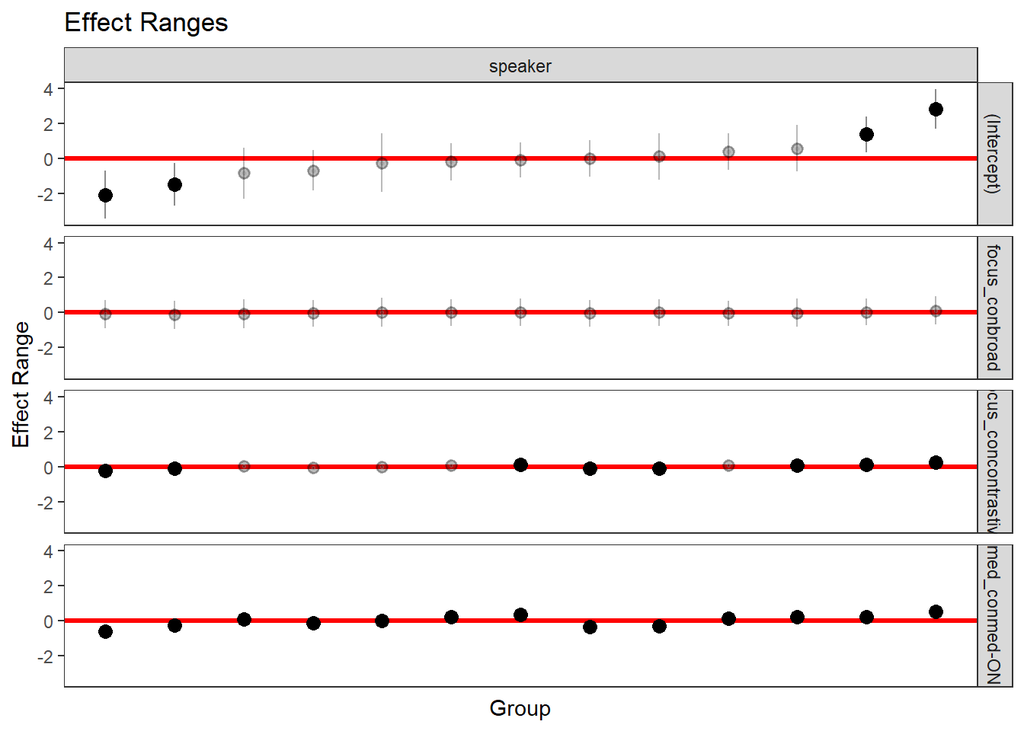

```r
randoms <- REsim(mdl2)
plotREsim(randoms)
```

Plot estimated 95 % interval spans for the intercept of TB amplitude

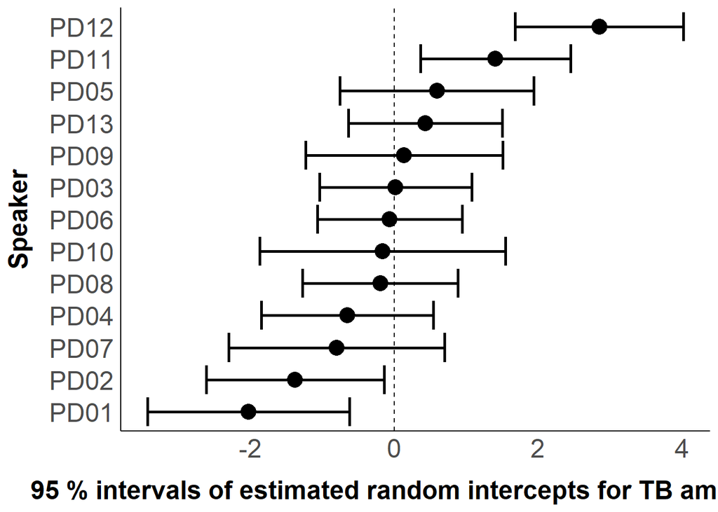

```r
random2 <- subset(randoms, term == "(Intercept)")

random2 %>%
  ggplot(aes(x = mean, xmin = mean-sd-sd, xmax = mean+sd+sd, y = reorder(groupID, mean))) +
  geom_vline(xintercept = 0, linetype = 'dashed') +
  geom_point(size = 5)+
  geom_errorbar(size = 1) +
  theme_classic()+
  xlab('95 % intervals of estimated random intercepts for TB amplitude') +
  ylab('Speaker')+
  theme(axis.title.y = element_text(face = 'bold', size = 18, margin = margin(r = 12)))+
  theme(axis.title.x = element_text(face = 'bold', size = 18, margin = margin(t = 12)))+
  theme(strip.text.x = element_text(size=18, face="bold"),
        strip.background = element_blank())+
  theme(axis.text.x = element_text(size = 18),
        axis.text.y = element_text(size = 18)) +
  theme(axis.ticks.x = element_blank(),
        axis.ticks.y = element_blank())+
  theme(legend.position = "top",
        legend.title = element_blank(),
        legend.text = element_text(size = 18))
```

Plot estimated 95 % interval spans for the slopes of TB amplitude

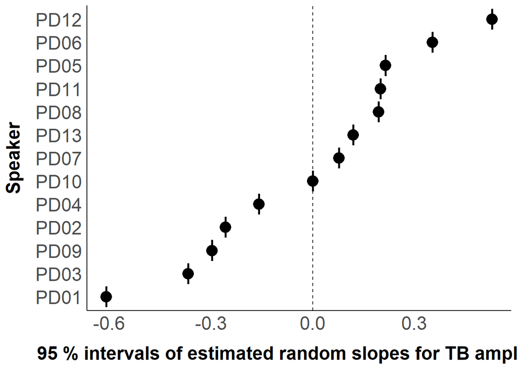

```r
random3 <- subset(randoms, term == "med_conmed-ON")

random3 %>%
  ggplot(aes(x = mean, xmin = mean-sd-sd, xmax = mean+sd+sd, y = reorder(groupID, mean))) +
  geom_vline(xintercept = 0, linetype = 'dashed') +
  geom_point(size = 5)+
  geom_errorbar(size = 1) +
  theme_classic()+
  xlab('95 % intervals of estimated random slopes for TB amplitude') +
  ylab('Speaker')+
  theme(axis.title.y = element_text(face = 'bold', size = 18, margin = margin(r = 12)))+
  theme(axis.title.x = element_text(face = 'bold', size = 18, margin = margin(t = 12)))+
  theme(strip.text.x = element_text(size=18, face="bold"),
        strip.background = element_blank())+
  theme(axis.text.x = element_text(size = 18),
        axis.text.y = element_text(size = 18)) +
  theme(axis.ticks.x = element_blank(),
        axis.ticks.y = element_blank())+
  theme(legend.position = "top",
        legend.title = element_blank(),
        legend.text = element_text(size = 18))
```

# Movement peak velocities

Descriptive stats for reporting values in Section 7.2.3

```r
PVEL_stats <- data_red %>%
  group_by(med_con) %>%
  summarise(M = round(mean(pvel_V1_abs)),
            SD = round(sd(pvel_V1_abs)))
PVEL_stats
```

```
## # A tibble: 2 x 3
##   med_con     M    SD
##   <chr>   <dbl> <dbl>
## 1 med-OFF    74    41
## 2 med-ON     77    44
```

```r
PVEL_stats2 <- data_red %>%
  group_by(med_con, focus_con) %>%
  summarise(M = round(mean(pvel_V1_abs)),
            SD = round(sd(pvel_V1_abs)))
PVEL_stats2
```

```
## # A tibble: 6 x 4
## # Groups:   med_con [2]
##   med_con focus_con       M    SD
##   <chr>   <chr>       <dbl> <dbl>
## 1 med-OFF background     72    41
## 2 med-OFF broad          76    39
## 3 med-OFF contrastive    75    42
## 4 med-ON  background     75    44
## 5 med-ON  broad          77    45
## 6 med-ON  contrastive    80    42
```

Create linear mixed model to investigate disease effect on TB velocity

```r
mdl3 <- lmer(pvel_V1_abs ~ med_con + focus_con + vowel + cons + age  + (1 + focus_con+med_con|speaker), data_red, REML = FALSE)
```

Look at model summary

```r
summary(mdl3)
```

```
## Linear mixed model fit by maximum likelihood . t-tests use Satterthwaite's
##   method [lmerModLmerTest]
## Formula: pvel_V1_abs ~ med_con + focus_con + vowel + cons + age + (1 +
##     focus_con + med_con | speaker)
##    Data: data_red
##
##      AIC      BIC   logLik deviance df.resid
##   7257.6   7355.5  -3607.8   7215.6      763
##
## Scaled residuals:
##     Min      1Q  Median      3Q     Max
## -5.4383 -0.5818 -0.0648  0.6189  3.8250
##
## Random effects:
##  Groups   Name                 Variance Std.Dev. Corr
##  speaker  (Intercept)          207.598  14.408
##           focus_conbroad         8.995   2.999   -0.37
##           focus_concontrastive  22.761   4.771    0.02  0.62
##           med_conmed-ON         58.346   7.638    0.10 -0.86 -0.26
##  Residual                      539.374  23.224
## Number of obs: 784, groups:  speaker, 13
##
## Fixed effects:
##                      Estimate Std. Error       df t value Pr(>|t|)
## (Intercept)           58.2457    29.4948  13.1909   1.975   0.0696 .
## med_conmed-ON          3.2710     2.6910  13.1332   1.216   0.2456
## focus_conbroad         2.6918     2.1940  35.6474   1.227   0.2279
## focus_concontrastive   3.1255     2.4229  13.3673   1.290   0.2189
## vowele               -71.3766     2.6033 746.2614 -27.418  < 2e-16 ***
## voweli               -51.9550     2.6523 745.8053 -19.588  < 2e-16 ***
## vowelo               -33.1845     2.6344 745.5176 -12.597  < 2e-16 ***
## vowelu               -84.3952     2.6300 745.3815 -32.090  < 2e-16 ***
## conslab               13.1743     1.6594 745.6449   7.939 7.47e-15 ***
## age                    0.9485     0.4941  13.0079   1.920   0.0771 .
## ---
## Signif. codes:  0 '***' 0.001 '**' 0.01 '*' 0.05 '.' 0.1 ' ' 1
##
## Correlation of Fixed Effects:
##             (Intr) md_-ON fcs_cnb fcs_cnc vowele voweli vowelo vowelu conslb
## med_cnmd-ON -0.008
## focus_cnbrd -0.051 -0.256
## fcs_cncntrs -0.028 -0.110  0.514
## vowele      -0.048 -0.001  0.004   0.008
## voweli      -0.042  0.004  0.005   0.002   0.503
## vowelo      -0.043  0.001  0.007   0.004   0.508  0.498
## vowelu      -0.045  0.002  0.004   0.004   0.508  0.499  0.502
## conslab     -0.027  0.005  0.003   0.002   0.002 -0.006 -0.006 -0.004
## age         -0.987  0.001  0.000   0.000   0.003 -0.003 -0.002  0.000 -0.001
## optimizer (nloptwrap) convergence code: 0 (OK)
## boundary (singular) fit: see help('isSingular')
```

extracting fit statistics for reporting in text

```r
tab_model(mdl3)
```

|  | pvel V 1 abs |  |  |
| --- | --- | --- | --- |
| Predictors | Estimates | CI | p |
| (Intercept) | 58.25 | 0.35 – 116.15 | **0.049** |
| med con [med-ON] | 3.27 | -2.01 – 8.55 | 0.225 |
| focus con [broad] | 2.69 | -1.62 – 7.00 | 0.220 |
| focus con [contrastive] | 3.13 | -1.63 – 7.88 | 0.197 |
| vowel [e] | -71.38 | -76.49 – -66.27 | **<0.001** |
| vowel [i] | -51.96 | -57.16 – -46.75 | **<0.001** |
| vowel [o] | -33.18 | -38.36 – -28.01 | **<0.001** |
| vowel [u] | -84.40 | -89.56 – -79.23 | **<0.001** |
| cons [lab] | 13.17 | 9.92 – 16.43 | **<0.001** |
| age | 0.95 | -0.02 – 1.92 | 0.055 |
| Random Effects |  |  |  |
| σ<sup>2</sup> | 539.37 |  |  |
| τ<sub>00</sub> <sub>speaker</sub> | 207.60 |  |  |
| τ<sub>11</sub> <sub>speaker.focus_conbroad</sub> | 9.00 |  |  |
| τ<sub>11</sub> <sub>speaker.focus_concontrastive</sub> | 22.76 |  |  |
| τ<sub>11</sub> <sub>speaker.med_conmed-ON</sub> | 58.35 |  |  |
| ρ<sub>01</sub> | -0.37 |  |  |
|  | 0.02 |  |  |
|  | 0.10 |  |  |
| N <sub>speaker</sub> | 13 |  |  |
| Observations | 784 |  |  |
| Marginal R<sup>2</sup> / Conditional R<sup>2</sup> | 0.647 / NA |  |  |

Explore random effects with function REsim

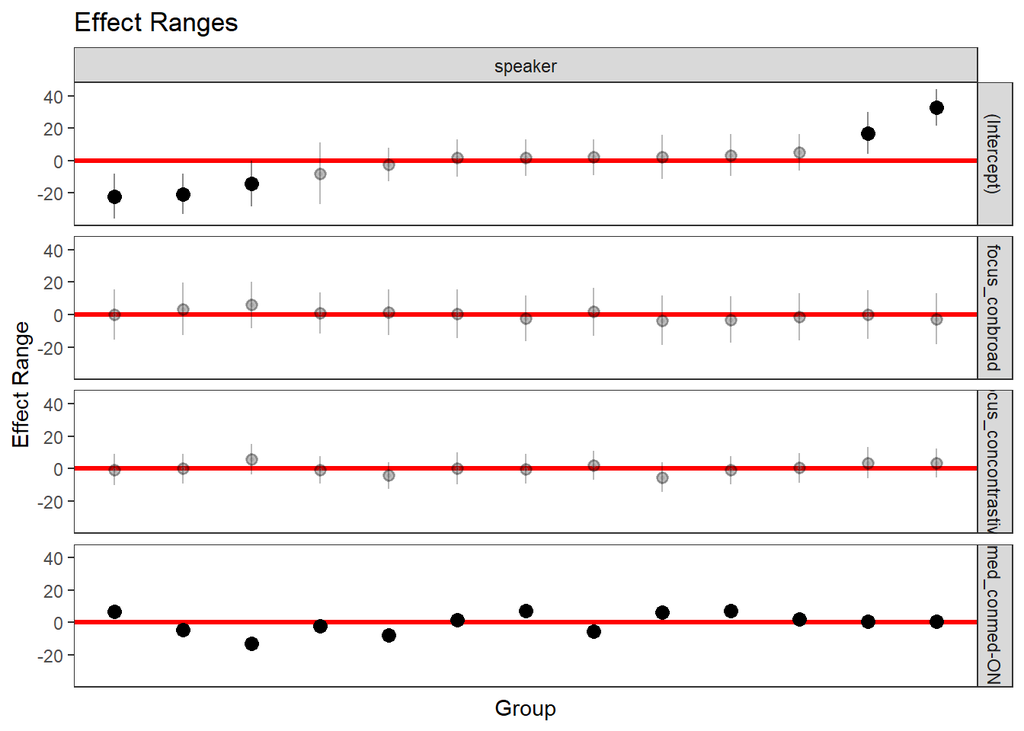

```r
randoms <- REsim(mdl3)
plotREsim(randoms)
```

Plot estimated 95 % interval spans for the intercept of TB velocity

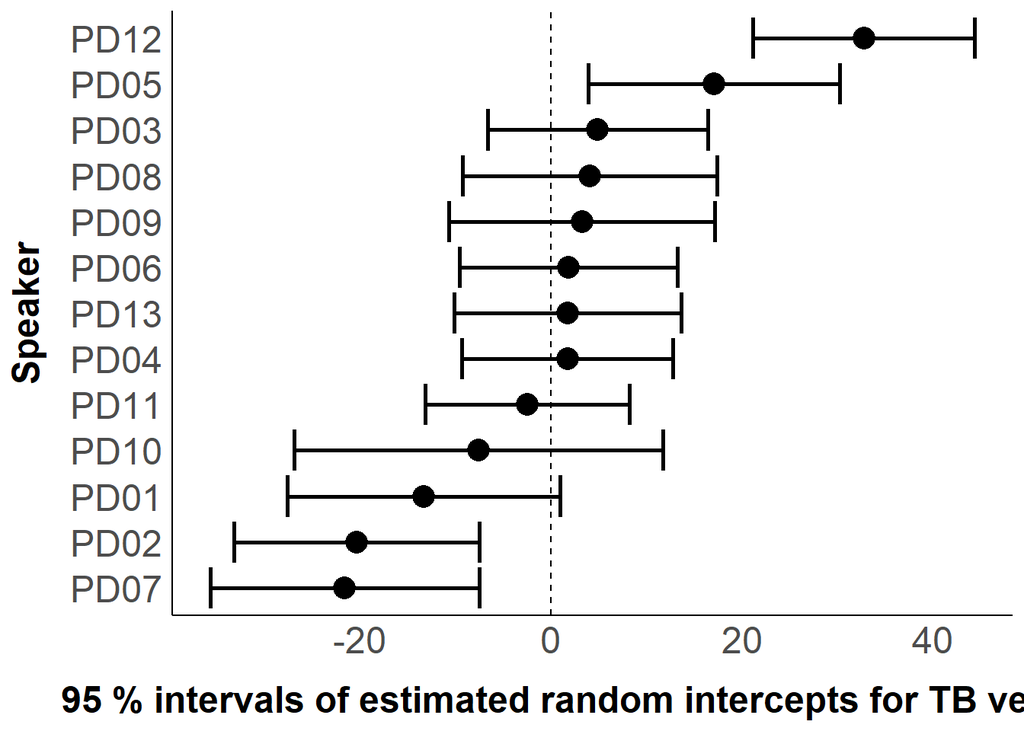

```r
random2 <- subset(randoms, term == "(Intercept)")

random2 %>%
  ggplot(aes(x = mean, xmin = mean-sd-sd, xmax = mean+sd+sd, y = reorder(groupID, mean))) +
  geom_vline(xintercept = 0, linetype = 'dashed') +
  geom_point(size = 5)+
  geom_errorbar(size = 1) +
  theme_classic()+
  xlab('95 % intervals of estimated random intercepts for TB velocity') +
  ylab('Speaker')+
  theme(axis.title.y = element_text(face = 'bold', size = 18, margin = margin(r = 12)))+
  theme(axis.title.x = element_text(face = 'bold', size = 18, margin = margin(t = 12)))+
  theme(strip.text.x = element_text(size=18, face="bold"),
        strip.background = element_blank())+
  theme(axis.text.x = element_text(size = 18),
        axis.text.y = element_text(size = 18)) +
  theme(axis.ticks.x = element_blank(),
        axis.ticks.y = element_blank())+
  theme(legend.position = "top",
        legend.title = element_blank(),
        legend.text = element_text(size = 18))
```

Plot estimated 95 % interval spans for the slopes of TB velocity

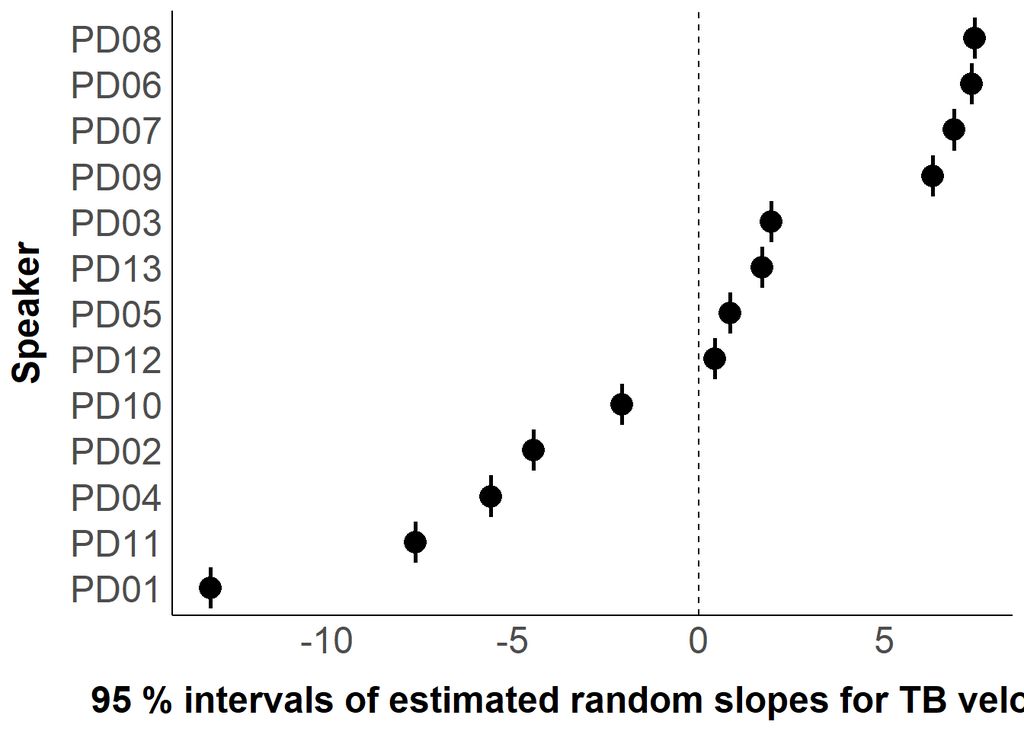

```r
random3 <- subset(randoms, term == "med_conmed-ON")

random3 %>%
  ggplot(aes(x = mean, xmin = mean-sd-sd, xmax = mean+sd+sd, y = reorder(groupID, mean))) +
  geom_vline(xintercept = 0, linetype = 'dashed') +
  geom_point(size = 5)+
  geom_errorbar(size = 1) +
  theme_classic()+
  xlab('95 % intervals of estimated random slopes for TB velocity') +
  ylab('Speaker')+
  theme(axis.title.y = element_text(face = 'bold', size = 18, margin = margin(r = 12)))+
  theme(axis.title.x = element_text(face = 'bold', size = 18, margin = margin(t = 12)))+
  theme(strip.text.x = element_text(size=18, face="bold"),
        strip.background = element_blank())+
  theme(axis.text.x = element_text(size = 18),
        axis.text.y = element_text(size = 18)) +
  theme(axis.ticks.x = element_blank(),
        axis.ticks.y = element_blank())+
  theme(legend.position = "top",
        legend.title = element_blank(),
        legend.text = element_text(size = 18))
```

# Movement Profiles

Descriptive stats for reporting values in Table 7.2

Subset for production of vowels /a/ and /i/

```r
data_red_i_a <-  filter(data_red, vowel %in% c('i', 'a'))
```

Acceleration phase

```r
ACC_stats <- data_red_i_a %>%
  group_by(med_con) %>%
  summarise(M = round(mean(acc_V1)),
            SD = round(sd(acc_V1)))
ACC_stats
```

```
## # A tibble: 2 x 3
##   med_con     M    SD
##   <chr>   <dbl> <dbl>
## 1 med-OFF    99    35
## 2 med-ON     92    32
```

```r
ACC_stats2 <- data_red_i_a %>%
  group_by(med_con, focus_con) %>%
  summarise(M = round(mean(acc_V1)),
            SD = round(sd(acc_V1)))
ACC_stats2
```

```
## # A tibble: 6 x 4
## # Groups:   med_con [2]
##   med_con focus_con       M    SD
##   <chr>   <chr>       <dbl> <dbl>
## 1 med-OFF background     95    34
## 2 med-OFF broad         102    39
## 3 med-OFF contrastive    99    31
## 4 med-ON  background     91    31
## 5 med-ON  broad          94    35
## 6 med-ON  contrastive    91    30
```

Deceleration phase

```r
DEC_stats <- data_red_i_a %>%
  group_by(med_con) %>%
  summarise(M = round(mean(dec_V1)),
            SD = round(sd(dec_V1)))
DEC_stats
```

```
## # A tibble: 2 x 3
##   med_con     M    SD
##   <chr>   <dbl> <dbl>
## 1 med-OFF   103    35
## 2 med-ON    100    36
```

```r
DEC_stats2 <- data_red_i_a %>%
  group_by(med_con, focus_con) %>%
  summarise(M = round(mean(dec_V1)),
            SD = round(sd(dec_V1)))
DEC_stats2
```

```
## # A tibble: 6 x 4
## # Groups:   med_con [2]
##   med_con focus_con       M    SD
##   <chr>   <chr>       <dbl> <dbl>
## 1 med-OFF background     98    33
## 2 med-OFF broad         102    33
## 3 med-OFF contrastive   109    39
## 4 med-ON  background     93    28
## 5 med-ON  broad         100    35
## 6 med-ON  contrastive   108    42
```

Symmetry profile

```r
SYMM_stats <- data_red_i_a %>%
  group_by(med_con) %>%
  summarise(M = round(mean(symmetry_V1),1),
            SD = round(sd(symmetry_V1),1))
SYMM_stats
```

```
## # A tibble: 2 x 3
##   med_con     M    SD
##   <chr>   <dbl> <dbl>
## 1 med-OFF   1.2   0.6
## 2 med-ON    1.2   0.6
```

```r
SYMM_stats2 <- data_red_i_a %>%
  group_by(med_con, focus_con) %>%
  summarise(M = round(mean(symmetry_V1),1),
            SD = round(sd(symmetry_V1),1))
SYMM_stats2
```

```
## # A tibble: 6 x 4
## # Groups:   med_con [2]
##   med_con focus_con       M    SD
##   <chr>   <chr>       <dbl> <dbl>
## 1 med-OFF background    1.2   0.6
## 2 med-OFF broad         1.2   0.6
## 3 med-OFF contrastive   1.3   0.7
## 4 med-ON  background    1.2   0.5
## 5 med-ON  broad         1.2   0.7
## 6 med-ON  contrastive   1.3   0.7
```

Stiffness

```r
STIFF_stats <- data_red_i_a %>%
  group_by(med_con) %>%
  summarise(M = round(mean(stiffness_V1_abs),1),
            SD = round(sd(stiffness_V1_abs),1))
STIFF_stats
```

```
## # A tibble: 2 x 3
##   med_con     M    SD
##   <chr>   <dbl> <dbl>
## 1 med-OFF   9.3   2
## 2 med-ON    9.8   2.1
```

```r
STIFF_stats2 <- data_red_i_a %>%
  group_by(med_con, focus_con) %>%
  summarise(M = round(mean(stiffness_V1_abs),1),
            SD = round(sd(stiffness_V1_abs),1))
STIFF_stats2
```

```
## # A tibble: 6 x 4
## # Groups:   med_con [2]
##   med_con focus_con       M    SD
##   <chr>   <chr>       <dbl> <dbl>
## 1 med-OFF background    9.7   1.9
## 2 med-OFF broad         9.3   2.1
## 3 med-OFF contrastive   9     2.1
## 4 med-ON  background   10     2
## 5 med-ON  broad         9.6   2.1
## 6 med-ON  contrastive   9.6   2.3
```

# Timing pattern

```r
ONS_avgs <- data_red %>%
  group_by(med_con) %>%
  summarise(M = round(mean(onsC1_to_onsV1)),
            SD = round(sd(onsC1_to_onsV1)))
ONS_avgs
```

```
## # A tibble: 2 x 3
##   med_con     M    SD
##   <chr>   <dbl> <dbl>
## 1 med-OFF    27    36
## 2 med-ON     28    34
```

```r
TARG_avgs <- data_red %>%
  group_by(med_con) %>%
  summarise(M = round(mean(targC1_to_targV1)),
            SD = round(sd(targC1_to_targV1)))
TARG_avgs
```

```
## # A tibble: 2 x 3
##   med_con     M    SD
##   <chr>   <dbl> <dbl>
## 1 med-OFF   119    37
## 2 med-ON    115    38
```

```r
OnsAlign_avgs <- data_red %>%
  group_by(med_con) %>%
  summarise(M = round(mean(onsV1.syll.dur),2)*100,
            SD = round(sd(onsV1.syll.dur),2)*100)
OnsAlign_avgs
```

```
## # A tibble: 2 x 3
##   med_con     M    SD
##   <chr>   <dbl> <dbl>
## 1 med-OFF   -19    17
## 2 med-ON    -17    14
```

```r
TargAlign_avgs <- data_red %>%
  group_by(med_con) %>%
  summarise(M = round(mean(targV1.syll.dur),2)*100,
            SD = round(sd(targV1.syll.dur),2)*100)
TargAlign_avgs
```

```
## # A tibble: 2 x 3
##   med_con     M    SD
##   <chr>   <dbl> <dbl>
## 1 med-OFF    69    11
## 2 med-ON     68    11
```

Statistical analysis for timing patterns

create model for onset to onset interval

```r
mdl4 <- lmer(onsC1_to_onsV1 ~ med_con + focus_con + vowel + cons + age  + (1 + focus_con+med_con|speaker), data_red, REML = FALSE)
```

Look at model

```r
summary(mdl4)
```

```
## Linear mixed model fit by maximum likelihood . t-tests use Satterthwaite's
##   method [lmerModLmerTest]
## Formula: onsC1_to_onsV1 ~ med_con + focus_con + vowel + cons + age + (1 +
##     focus_con + med_con | speaker)
##    Data: data_red
##
##      AIC      BIC   logLik deviance df.resid
##   7596.7   7694.7  -3777.4   7554.7      763
##
## Scaled residuals:
##     Min      1Q  Median      3Q     Max
## -2.3823 -0.6742 -0.0739  0.6226  9.1233
##
## Random effects:
##  Groups   Name                 Variance Std.Dev. Corr
##  speaker  (Intercept)          168.967  12.999
##           focus_conbroad        26.541   5.152    0.14
##           focus_concontrastive   7.665   2.769    0.14  1.00
##           med_conmed-ON         22.586   4.753    0.34 -0.88 -0.88
##  Residual                      849.395  29.144
## Number of obs: 784, groups:  speaker, 13
##
## Fixed effects:
##                      Estimate Std. Error       df t value Pr(>|t|)
## (Intercept)           27.1852    29.3144  13.3029   0.927  0.37026
## med_conmed-ON          0.6292     2.4643  17.5386   0.255  0.80143
## focus_conbroad         2.6779     2.9207  19.9213   0.917  0.37018
## focus_concontrastive   3.9678     2.6601  63.0092   1.492  0.14079
## vowele                10.7619     3.2665 758.9105   3.295  0.00103 **
## voweli                -3.7100     3.3281 758.4060  -1.115  0.26532
## vowelo                -2.3691     3.3057 758.2428  -0.717  0.47380
## vowelu                21.9815     3.3002 758.1120   6.661 5.24e-11 ***
## conslab               14.4330     2.0823 758.6756   6.931 8.91e-12 ***
## age                   -0.2531     0.4909  13.0861  -0.516  0.61471
## ---
## Signif. codes:  0 '***' 0.001 '**' 0.01 '*' 0.05 '.' 0.1 ' ' 1
##
## Correlation of Fixed Effects:
##             (Intr) md_-ON fcs_cnb fcs_cnc vowele voweli vowelo vowelu conslb
## med_cnmd-ON -0.008
## focus_cnbrd -0.030 -0.231
## fcs_cncntrs -0.038 -0.136  0.556
## vowele      -0.057 -0.001  0.004   0.009
## voweli      -0.053  0.005  0.004   0.002   0.504
## vowelo      -0.053  0.002  0.006   0.005   0.508  0.498
## vowelu      -0.056  0.003  0.004   0.005   0.508  0.499  0.502
## conslab     -0.039  0.006  0.003   0.003   0.002 -0.006 -0.006 -0.004
## age         -0.987  0.000  0.000   0.001  -0.001 -0.004 -0.004 -0.001  0.004
## optimizer (nloptwrap) convergence code: 0 (OK)
## boundary (singular) fit: see help('isSingular')
```

Extracting fit statistics for reporting in text

```r
tab_model(mdl4)
```

|  | ons C 1 to ons V 1 |  |  |
| --- | --- | --- | --- |
| Predictors | Estimates | CI | p |
| (Intercept) | 27.19 | -30.36 – 84.73 | 0.354 |
| med con [med-ON] | 0.63 | -4.21 – 5.47 | 0.799 |
| focus con [broad] | 2.68 | -3.06 – 8.41 | 0.360 |
| focus con [contrastive] | 3.97 | -1.25 – 9.19 | 0.136 |
| vowel [e] | 10.76 | 4.35 – 17.17 | **0.001** |
| vowel [i] | -3.71 | -10.24 – 2.82 | 0.265 |
| vowel [o] | -2.37 | -8.86 – 4.12 | 0.474 |
| vowel [u] | 21.98 | 15.50 – 28.46 | **<0.001** |
| cons [lab] | 14.43 | 10.35 – 18.52 | **<0.001** |
| age | -0.25 | -1.22 – 0.71 | 0.606 |
| Random Effects |  |  |  |
| σ<sup>2</sup> | 849.39 |  |  |
| τ<sub>00</sub> <sub>speaker</sub> | 168.97 |  |  |
| τ<sub>11</sub> <sub>speaker.focus_conbroad</sub> | 26.54 |  |  |
| τ<sub>11</sub> <sub>speaker.focus_concontrastive</sub> | 7.66 |  |  |
| τ<sub>11</sub> <sub>speaker.med_conmed-ON</sub> | 22.59 |  |  |
| ρ<sub>01</sub> | 0.14 |  |  |
|  | 0.14 |  |  |
|  | 0.34 |  |  |
| N <sub>speaker</sub> | 13 |  |  |
| Observations | 784 |  |  |
| Marginal R<sup>2</sup> / Conditional R<sup>2</sup> | 0.153 / NA |  |  |

create model for target to target interval

```r
mdl5 <- lmer(targC1_to_targV1 ~ med_con + focus_con + vowel + cons + age  + (1 + focus_con+med_con|speaker), data_red, REML = FALSE)
```

Look at model

```r
summary(mdl5)
```

```
## Linear mixed model fit by maximum likelihood . t-tests use Satterthwaite's
##   method [lmerModLmerTest]
## Formula: targC1_to_targV1 ~ med_con + focus_con + vowel + cons + age +
##     (1 + focus_con + med_con | speaker)
##    Data: data_red
##
##      AIC      BIC   logLik deviance df.resid
##   7483.6   7581.5  -3720.8   7441.6      763
##
## Scaled residuals:
##     Min      1Q  Median      3Q     Max
## -3.3726 -0.5224 -0.0207  0.5513  5.2724
##
## Random effects:
##  Groups   Name                 Variance Std.Dev. Corr
##  speaker  (Intercept)          321.57   17.932
##           focus_conbroad        12.19    3.492   0.99
##           focus_concontrastive  37.29    6.107   1.00 1.00
##           med_conmed-ON         85.18    9.229   0.13 0.28 0.19
##  Residual                      717.45   26.785
## Number of obs: 784, groups:  speaker, 13
##
## Fixed effects:
##                      Estimate Std. Error       df t value Pr(>|t|)
## (Intercept)           53.9073    36.3317  15.4582   1.484 0.157977
## med_conmed-ON         -4.0326     3.1960  12.9940  -1.262 0.229212
## focus_conbroad         7.7948     2.5337  45.6131   3.076 0.003536 **
## focus_concontrastive  13.3866     2.8894  22.2025   4.633 0.000126 ***
## vowele               -16.1281     3.0018 758.0767  -5.373 1.03e-07 ***
## voweli               -28.7398     3.0589 758.0637  -9.396  < 2e-16 ***
## vowelo               -20.6640     3.0382 757.9561  -6.801 2.10e-11 ***
## vowelu               -16.0480     3.0332 757.9014  -5.291 1.60e-07 ***
## conslab               -6.5294     1.9137 758.1158  -3.412 0.000679 ***
## age                    1.3106     0.6088  15.3265   2.153 0.047656 *
## ---
## Signif. codes:  0 '***' 0.001 '**' 0.01 '*' 0.05 '.' 0.1 ' ' 1
##
## Correlation of Fixed Effects:
##             (Intr) md_-ON fcs_cnb fcs_cnc vowele voweli vowelo vowelu conslb
## med_cnmd-ON -0.001
## focus_cnbrd  0.020  0.085
## fcs_cncntrs  0.052  0.090  0.595
## vowele      -0.039 -0.001  0.004   0.008
## voweli      -0.036  0.004  0.005   0.002   0.504
## vowelo      -0.035  0.001  0.007   0.004   0.508  0.498
## vowelu      -0.040  0.002  0.004   0.004   0.508  0.499  0.502
## conslab     -0.035  0.004  0.003   0.002   0.002 -0.006 -0.006 -0.004
## age         -0.987 -0.001  0.002   0.002  -0.004 -0.006 -0.007 -0.002  0.008
## optimizer (nloptwrap) convergence code: 0 (OK)
## boundary (singular) fit: see help('isSingular')
```

Extracting fit statistics for reporting in text

```r
tab_model(mdl5)
```

|  | targ C 1 to targ V 1 |  |  |
| --- | --- | --- | --- |
| Predictors | Estimates | CI | p |
| (Intercept) | 53.91 | -17.41 – 125.23 | 0.138 |
| med con [med-ON] | -4.03 | -10.31 – 2.24 | 0.207 |
| focus con [broad] | 7.79 | 2.82 – 12.77 | **0.002** |
| focus con [contrastive] | 13.39 | 7.71 – 19.06 | **<0.001** |
| vowel [e] | -16.13 | -22.02 – -10.24 | **<0.001** |
| vowel [i] | -28.74 | -34.74 – -22.74 | **<0.001** |
| vowel [o] | -20.66 | -26.63 – -14.70 | **<0.001** |
| vowel [u] | -16.05 | -22.00 – -10.09 | **<0.001** |
| cons [lab] | -6.53 | -10.29 – -2.77 | **0.001** |
| age | 1.31 | 0.12 – 2.51 | **0.032** |
| Random Effects |  |  |  |
| σ<sup>2</sup> | 717.45 |  |  |
| τ<sub>00</sub> <sub>speaker</sub> | 321.57 |  |  |
| τ<sub>11</sub> <sub>speaker.focus_conbroad</sub> | 12.19 |  |  |
| τ<sub>11</sub> <sub>speaker.focus_concontrastive</sub> | 37.29 |  |  |
| τ<sub>11</sub> <sub>speaker.med_conmed-ON</sub> | 85.18 |  |  |
| ρ<sub>01</sub> | 0.99 |  |  |
|  | 1.00 |  |  |
|  | 0.13 |  |  |
| N <sub>speaker</sub> | 13 |  |  |
| Observations | 784 |  |  |
| Marginal R<sup>2</sup> / Conditional R<sup>2</sup> | 0.253 / NA |  |  |

create model for onset alignment

```r
mdl6 <- lmer(onsV1.syll.dur ~ med_con + focus_con + vowel + cons + age  + (1 + focus_con+med_con|speaker), data_red, REML = FALSE)
```

Look at model

```r
summary(mdl6)
```

```
## Linear mixed model fit by maximum likelihood . t-tests use Satterthwaite's
##   method [lmerModLmerTest]
## Formula: onsV1.syll.dur ~ med_con + focus_con + vowel + cons + age + (1 +
##     focus_con + med_con | speaker)
##    Data: data_red
##
##      AIC      BIC   logLik deviance df.resid
##   -967.5   -869.5    504.7  -1009.5      763
##
## Scaled residuals:
##     Min      1Q  Median      3Q     Max
## -7.3014 -0.6570  0.0306  0.6756  3.1995
##
## Random effects:
##  Groups   Name                 Variance  Std.Dev. Corr
##  speaker  (Intercept)          6.146e-03 0.078394
##           focus_conbroad       2.045e-05 0.004522  0.22
##           focus_concontrastive 3.321e-04 0.018223 -1.00 -0.25
##           med_conmed-ON        1.954e-03 0.044208 -0.48  0.75  0.45
##  Residual                      1.512e-02 0.122975
## Number of obs: 784, groups:  speaker, 13
##
## Fixed effects:
##                        Estimate Std. Error         df t value Pr(>|t|)
## (Intercept)           -0.157693   0.121811  14.592542  -1.295  0.21558
## med_conmed-ON          0.022127   0.015084  13.011969   1.467  0.16615
## focus_conbroad         0.020653   0.010824 276.905400   1.908  0.05741 .
## focus_concontrastive   0.037920   0.011877  35.337911   3.193  0.00296 **
## vowele                 0.015156   0.013783 757.526040   1.100  0.27183
## voweli                -0.062364   0.014044 757.536482  -4.441 1.03e-05 ***
## vowelo                -0.022399   0.013949 757.405063  -1.606  0.10875
## vowelu                 0.070028   0.013926 757.354425   5.029 6.17e-07 ***
## conslab                0.094421   0.008786 757.489238  10.747  < 2e-16 ***
## age                   -0.001789   0.002022  13.941255  -0.885  0.39107
## ---
## Signif. codes:  0 '***' 0.001 '**' 0.01 '*' 0.05 '.' 0.1 ' ' 1
##
## Correlation of Fixed Effects:
##             (Intr) md_-ON fcs_cnb fcs_cnc vowele voweli vowelo vowelu conslb
## med_cnmd-ON -0.090
## focus_cnbrd -0.040  0.071
## fcs_cncntrs -0.116  0.156  0.434
## vowele      -0.058 -0.001  0.005   0.009
## voweli      -0.057  0.004  0.005   0.002   0.504
## vowelo      -0.058  0.001  0.007   0.004   0.508  0.498
## vowelu      -0.058  0.002  0.005   0.004   0.508  0.499  0.502
## conslab     -0.037  0.004  0.003   0.003   0.002 -0.006 -0.006 -0.004
## age         -0.978 -0.001  0.000   0.000   0.000  0.000  0.000  0.000  0.001
## optimizer (nloptwrap) convergence code: 0 (OK)
## boundary (singular) fit: see help('isSingular')
```

Extracting fit statistics for reporting in text

```r
tab_model(mdl6)
```

|  | ons V 1.syll dur |  |  |
| --- | --- | --- | --- |
| Predictors | Estimates | CI | p |
| (Intercept) | -0.16 | -0.40 – 0.08 | 0.196 |
| med con [med-ON] | 0.02 | -0.01 – 0.05 | 0.143 |
| focus con [broad] | 0.02 | -0.00 – 0.04 | 0.057 |
| focus con [contrastive] | 0.04 | 0.01 – 0.06 | **0.001** |
| vowel [e] | 0.02 | -0.01 – 0.04 | 0.272 |
| vowel [i] | -0.06 | -0.09 – -0.03 | **<0.001** |
| vowel [o] | -0.02 | -0.05 – 0.00 | 0.109 |
| vowel [u] | 0.07 | 0.04 – 0.10 | **<0.001** |
| cons [lab] | 0.09 | 0.08 – 0.11 | **<0.001** |
| age | -0.00 | -0.01 – 0.00 | 0.376 |
| Random Effects |  |  |  |
| σ<sup>2</sup> | 0.02 |  |  |
| τ<sub>00</sub> <sub>speaker</sub> | 0.01 |  |  |
| τ<sub>11</sub> <sub>speaker.focus_conbroad</sub> | 0.00 |  |  |
| τ<sub>11</sub> <sub>speaker.focus_concontrastive</sub> | 0.00 |  |  |
| τ<sub>11</sub> <sub>speaker.med_conmed-ON</sub> | 0.00 |  |  |
| ρ<sub>01</sub> | 0.22 |  |  |
|  | -1.00 |  |  |
|  | -0.48 |  |  |
| N <sub>speaker</sub> | 13 |  |  |
| Observations | 784 |  |  |
| Marginal R<sup>2</sup> / Conditional R<sup>2</sup> | 0.236 / NA |  |  |

create model for target alignment

```r
mdl7 <- lmer(targV1.syll.dur ~ med_con + focus_con + vowel + cons + age + (1 + focus_con+med_con|speaker), data_red, REML = FALSE)
```

Look at model

```r
summary(mdl7)
```

```
## Linear mixed model fit by maximum likelihood . t-tests use Satterthwaite's
##   method [lmerModLmerTest]
## Formula: targV1.syll.dur ~ med_con + focus_con + vowel + cons + age +
##     (1 + focus_con + med_con | speaker)
##    Data: data_red
##
##      AIC      BIC   logLik deviance df.resid
##  -1416.3  -1318.4    729.2  -1458.3      763
##
## Scaled residuals:
##     Min      1Q  Median      3Q     Max
## -3.8746 -0.5597  0.0148  0.6035  3.4184
##
## Random effects:
##  Groups   Name                 Variance  Std.Dev. Corr
##  speaker  (Intercept)          5.896e-04 0.024282
##           focus_conbroad       5.019e-06 0.002240 -0.84
##           focus_concontrastive 7.173e-05 0.008469  0.69 -0.19
##           med_conmed-ON        1.271e-04 0.011273  0.10  0.46  0.79
##  Residual                      8.814e-03 0.093882
## Number of obs: 784, groups:  speaker, 13
##
## Fixed effects:
##                        Estimate Std. Error         df t value Pr(>|t|)
## (Intercept)           5.885e-01  5.864e-02  1.389e+01  10.035 9.57e-08 ***
## med_conmed-ON        -6.553e-03  7.400e-03  1.407e+01  -0.886 0.390728
## focus_conbroad       -1.020e-03  8.229e-03  4.308e+02  -0.124 0.901374
## focus_concontrastive  6.364e-04  8.534e-03  5.624e+01   0.075 0.940814
## vowele                5.768e-02  1.052e-02  7.584e+02   5.483 5.70e-08 ***
## voweli                6.182e-02  1.072e-02  7.585e+02   5.766 1.18e-08 ***
## vowelo               -3.712e-02  1.065e-02  7.583e+02  -3.486 0.000519 ***
## vowelu                7.989e-02  1.063e-02  7.582e+02   7.515 1.61e-13 ***
## conslab              -1.896e-02  6.707e-03  7.584e+02  -2.827 0.004820 **
## age                   1.290e-03  9.735e-04  1.322e+01   1.325 0.207462
## ---
## Signif. codes:  0 '***' 0.001 '**' 0.01 '*' 0.05 '.' 0.1 ' ' 1
##
## Correlation of Fixed Effects:
##             (Intr) md_-ON fcs_cnb fcs_cnc vowele voweli vowelo vowelu conslb
## med_cnmd-ON -0.050
## focus_cnbrd -0.080  0.015
## fcs_cncntrs -0.047  0.091  0.472
## vowele      -0.095 -0.001  0.005   0.009
## voweli      -0.085  0.005  0.005   0.002   0.504
## vowelo      -0.087  0.002  0.007   0.005   0.508  0.498
## vowelu      -0.090  0.004  0.005   0.005   0.509  0.499  0.502
## conslab     -0.059  0.007  0.003   0.003   0.002 -0.006 -0.006 -0.004
## age         -0.978  0.002  0.003   0.002   0.002 -0.006 -0.005 -0.001  0.001
## optimizer (nloptwrap) convergence code: 0 (OK)
## boundary (singular) fit: see help('isSingular')
```

Extracting fit statistics for reporting in text

```r
tab_model(mdl7)
```

|  | targ V 1.syll dur |  |  |
| --- | --- | --- | --- |
| Predictors | Estimates | CI | p |
| (Intercept) | 0.59 | 0.47 – 0.70 | **<0.001** |
| med con [med-ON] | -0.01 | -0.02 – 0.01 | 0.376 |
| focus con [broad] | -0.00 | -0.02 – 0.02 | 0.901 |
| focus con [contrastive] | 0.00 | -0.02 – 0.02 | 0.941 |
| vowel [e] | 0.06 | 0.04 – 0.08 | **<0.001** |
| vowel [i] | 0.06 | 0.04 – 0.08 | **<0.001** |
| vowel [o] | -0.04 | -0.06 – -0.02 | **0.001** |
| vowel [u] | 0.08 | 0.06 – 0.10 | **<0.001** |
| cons [lab] | -0.02 | -0.03 – -0.01 | **0.005** |
| age | 0.00 | -0.00 – 0.00 | 0.185 |
| Random Effects |  |  |  |
| σ<sup>2</sup> | 0.01 |  |  |
| τ<sub>00</sub> <sub>speaker</sub> | 0.00 |  |  |
| τ<sub>11</sub> <sub>speaker.focus_conbroad</sub> | 0.00 |  |  |
| τ<sub>11</sub> <sub>speaker.focus_concontrastive</sub> | 0.00 |  |  |
| τ<sub>11</sub> <sub>speaker.med_conmed-ON</sub> | 0.00 |  |  |
| ρ<sub>01</sub> | -0.84 |  |  |
|  | 0.69 |  |  |
|  | 0.10 |  |  |
| N <sub>speaker</sub> | 13 |  |  |
| Observations | 784 |  |  |
| Marginal R<sup>2</sup> / Conditional R<sup>2</sup> | 0.195 / NA |  |  |